# Applied Finance: European Up-and-In Put Option

Path-dependent option pricing with Monte Carlo and the `Rcpp` package

Dustin Pacholleck - 437968

Academic Year 2022/2023

# Objective

This project aims to use Monte Carlo Simulation for pricing a European style up-and-in put option with a barrier active between the moment of pricing and the option expiry.

Specifically, the project tries to:

1. find the theoretical price of the given option,
2. show the relation between the theoretical price of the given option and two factors (simultaneously):
   1. volatility of the underlying instrument returns, and
   2. time to maturity of the option.

It tries to achieve so, by building a `rccp` package.

# Assumptions

The project assumes:

- 10,000 Monte Carlo simulations,
- 252 number of time steps per year, and
- defining the barrier after inspection of its effect.

# Description of the Option

The given option is described as followed:

- price of the underlying at the moment of option pricing: $S0 = 95$,
- strike price $K = 100$,
- annualized volatility rate $\sigma = 0.24$
- annualized risk-free rate $r = 0.07$
- time to maturity $t = 0.75$

A holder of an European option can exercise only at exercise date. The option includes an Up-and-In barrier which means the underlying price has to be higher than the barrier to activate the option.

In finance, an **option** is an agreement, which gives the holder a right for **buy** or **sell** a certain underlying instrument for a given price (*exercise price*) at a given moment in futures (*expiry date*). **PUT** option – gives the holder right to **sell** a given amount of underlying instrument for a given price at the given moment in future. `(Source: Lecture Slides)`

# Interpretation of the results

## Determining the Barrier

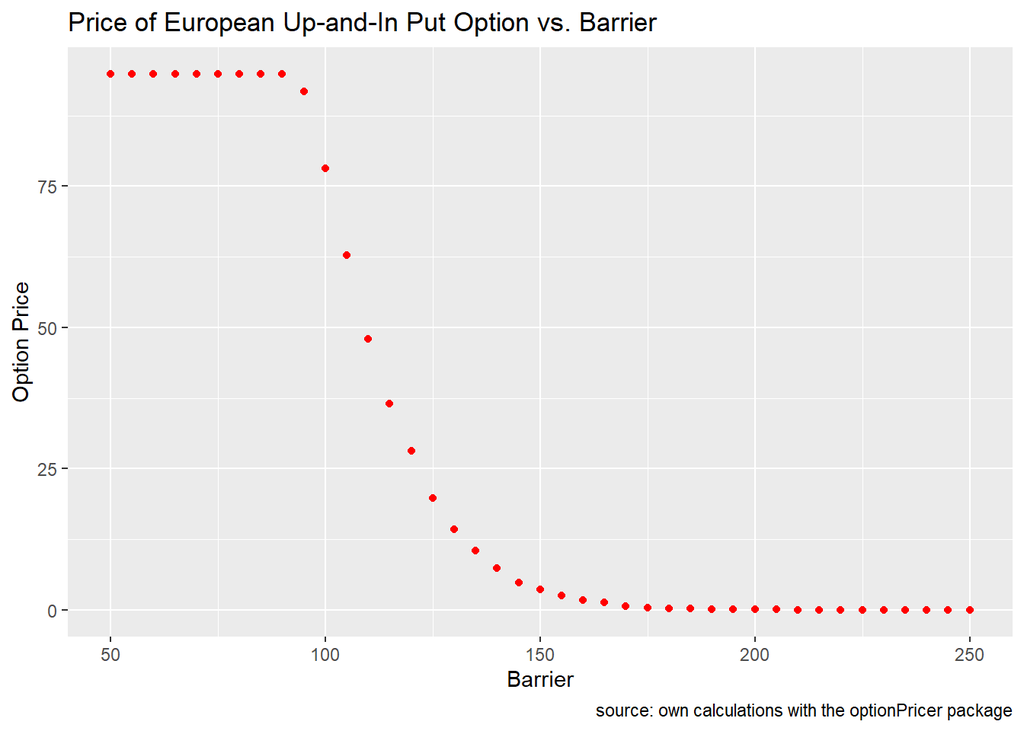

The barrier seems to have an effect within the range of 90 to 160 on the option price. Therefore, for this project we will assume the barrier to be $B = 125$.

## Calculating the Theoretical Price

The theoretical option price is estimated to be **20.7799096** for the given option.

## Investigating the Relationship of Price, Volatility and Time to Maturity

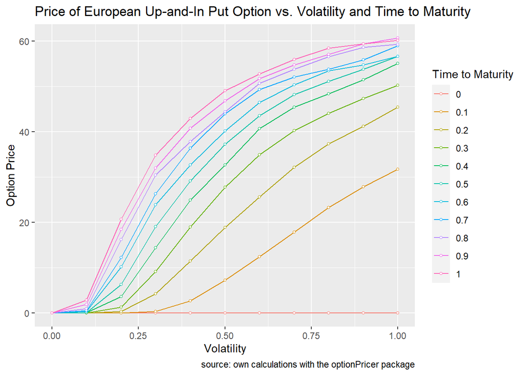

1. **time to maturity** – influences positively the put option values. The longer the time to maturity, the higher the probability that the option becomes active and in-the-money.
2. **volatility of underlying prices** – influences positively the put option values. The higher the volatility, the higher the probability that the option becomes active and in-the-money.

# Code of Honor

In accordance with the Honor Code, I certify that my answers here are my own work, and I did not make my solutions available to anyone else.